# We’re not stringing you along!

PUBH 7462 - Week 7 Activity

Authors

Eric Lock

Thanks to Michael Anderson, Biyue Dai, Kollin Rott, and Julian Wolfson

## Working With Strings!

It is a truth universally acknowledged, that a single activity about strings, must be in want of a good data set.

```r
# install.pacakages('janeaustenr')
# install.pacakages('lubridate')
library(tidyverse)
library(lubridate)
library(janeaustenr)
library(knitr) # needed for kable function

data("prideprejudice")

head(prideprejudice, 10) # some stuff at beginning to remove
```

```
 [1] "PRIDE AND PREJUDICE"
 [2] ""
 [3] "By Jane Austen"
 [4] ""
 [5] ""
 [6] ""
 [7] "Chapter 1"
 [8] ""
 [9] ""
[10] "It is a truth universally acknowledged, that a single man in possession"
```

```r
tail(prideprejudice) # end looks fine!
```

```
[1] "visits of her uncle and aunt from the city."
[2] ""
[3] "With the Gardiners, they were always on the most intimate terms."
[4] "Darcy, as well as Elizabeth, really loved them; and they were both ever"
[5] "sensible of the warmest gratitude towards the persons who, by bringing"
[6] "her into Derbyshire, had been the means of uniting them."
```

We have the entire text of Jane Austen’s seminal novel *Pride and Prejudice*; in fact, we have a bit more than we want. Let’s remove the first couple lines (the title and author info) and all the empty elements, which correspond to line breaks etc.

```r
pandp.words <- prideprejudice[prideprejudice != ""]
pandp.words <- pandp.words[-c(1,2)]
```

There are obviously still some things we need to do in order to just get the main text. First, we would like to remove the elements that are simply chapter headings. See if you can figure it out using `str_subset`.

```
 [1] "It is a truth universally acknowledged, that a single man in possession"
 [2] "of a good fortune, must be in want of a wife."
 [3] "However little known the feelings or views of such a man may be on his"
 [4] "first entering a neighbourhood, this truth is so well fixed in the minds"
 [5] "of the surrounding families, that he is considered the rightful property"
 [6] "of some one or other of their daughters."
 [7] "\"My dear Mr. Bennet,\" said his lady to him one day, \"have you heard that"
 [8] "Netherfield Park is let at last?\""
 [9] "Mr. Bennet replied that he had not."
[10] "\"But it is,\" returned she; \"for Mrs. Long has just been here, and she"
```

We can remove punctuation using `str_remove_all`. See if you can remove all of the non-letter characters! Save the removed output as object `pandp.words.only`.

```
 [1] "It is a truth universally acknowledged that a single man in possession"
 [2] "of a good fortune must be in want of a wife"
 [3] "However little known the feelings or views of such a man may be on his"
 [4] "first entering a neighbourhood this truth is so well fixed in the minds"
 [5] "of the surrounding families that he is considered the rightful property"
 [6] "of some one or other of their daughters"
 [7] "My dear Mr Bennet said his lady to him one day have you heard that"
 [8] "Netherfield Park is let at last"
 [9] "Mr Bennet replied that he had not"
[10] "But it is returned she for Mrs Long has just been here and she"
```

There are just a couple more things to do! First, so that words at the beginning of sentences aren’t treated differently than if they occur later, it is common to make everything lowercase. This can be done with the base R function `tolower`. Save the result of the `tolower` operation as `pandp.words.only`. The next code shows results of command `head(pandp.words.only,10)`.

```
 [1] "it is a truth universally acknowledged that a single man in possession"
 [2] "of a good fortune must be in want of a wife"
 [3] "however little known the feelings or views of such a man may be on his"
 [4] "first entering a neighbourhood this truth is so well fixed in the minds"
 [5] "of the surrounding families that he is considered the rightful property"
 [6] "of some one or other of their daughters"
 [7] "my dear mr bennet said his lady to him one day have you heard that"
 [8] "netherfield park is let at last"
 [9] "mr bennet replied that he had not"
[10] "but it is returned she for mrs long has just been here and she"
```

Lastly, let’s split the elements up so that each word is its own element! You can start this using `str_split`, save the result as `pandp`. Do you know an easy way to *unlist* a list into a character vector?

```
 [1] "it"           "is"           "a"            "truth"        "universally"
 [6] "acknowledged" "that"         "a"            "single"       "man"
[11] "in"           "possession"   "of"           "a"            "good"
[16] "fortune"      "must"         "be"           "in"           "want"
[21] "of"           "a"            "wife"         "however"      "little"
```

The final command in the last code block was `head(pandp,25)`.

Awesome! We now have the full text of *Pride and Prejudice* word by word, and we’ve gotten to practice with strings!

Try writing a sentence using `str_glue` that shows how many times the words “pride” and “prejudice” appear in the novel.

```
The word 'pride' appears 44 times and the word 'prejudice' appears 5 times.
```

## The date/time format is snow joke!

```r
precip <- read.csv('mn_precip.csv')

head(precip)
```

```
      date maxtemp.f mintemp.f precip.in snow.in snowdepth.in
1 1/1/2010         6        -9         T       T            9
2 1/2/2010         1       -15         0       0            9
3 1/3/2010         7       -14         0       0            9
4 1/4/2010         7       -10         0       0            9
5 1/5/2010        10        -9         0       0            9
6 1/6/2010        16        -4         0       0            9
```

We’ve uploaded a `csv` file to Canvas with daily precipitation data for the Twin Cities from the beginning of 2010 through a year ago. We’re going to examine dates in a moment, but you may notice we have some other problems to deal with first.

The “T” in some of the columns refers to trace amounts. The measurements are only to the hundredths place, so any amount of precipitation/snowfall that is not zero but is less than 0.01 inches is marked as trace. Note that because of this character appearing, those columns have been read in as character vectors. We will obviously want to fix that. Let’s impute that with a value of 0.005, the middle ground between 0 and 0.01. (If you would like to challenge yourself, you can try to instead impute the trace amounts with a different random value between 0 and 0.01 for each instance.)

```
      date maxtemp.f mintemp.f precip.in snow.in snowdepth.in
1 1/1/2010         6        -9     0.005   0.005            9
2 1/2/2010         1       -15         0       0            9
3 1/3/2010         7       -14         0       0            9
4 1/4/2010         7       -10         0       0            9
5 1/5/2010        10        -9         0       0            9
6 1/6/2010        16        -4         0       0            9
```

Note that even though all our variables that should be numeric now have only numbers, they remain character vectors until we tell them otherwise. We want to change the date and the precipitation/snowfall variables from character to their respective formats.

```
'data.frame':   5207 obs. of  6 variables:
 $ date        : Date, format: "2010-01-01" "2010-01-02" ...
 $ maxtemp.f   : int  6 1 7 7 10 16 16 8 6 15 ...
 $ mintemp.f   : int  -9 -15 -14 -10 -9 -4 4 -6 -14 -6 ...
 $ precip.in   : num  0.005 0 0 0 0 0 0.06 0 0 0 ...
 $ snow.in     : num  0.005 0 0 0 0 0 2.2 0 0 0 ...
 $ snowdepth.in: num  9 9 9 9 9 9 11 11 11 11 ...
```

Now we have a workable data set, with the proper dates and variable types! Let’s plot daily snowfall over time.

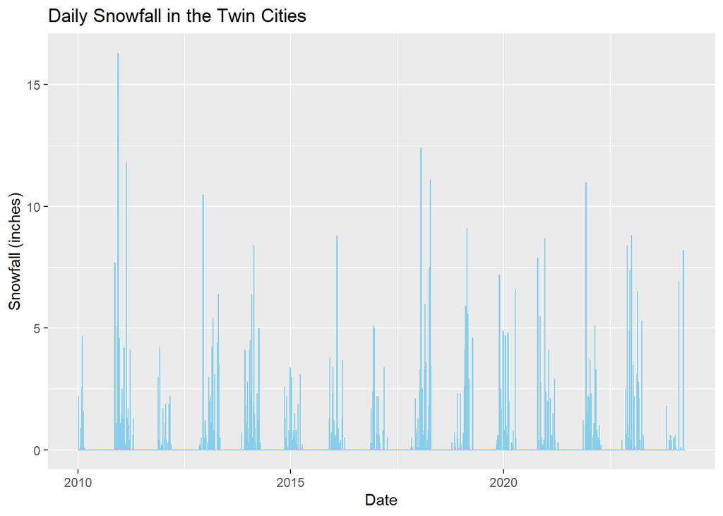

| Year | Snowfall (inches) | Snow Days |
| --- | --- | --- |
| 2010 | 60.540 | 30 |
| 2011 | 51.720 | 42 |
| 2012 | 27.905 | 32 |
| 2013 | 50.620 | 41 |
| 2014 | 60.940 | 42 |
| 2015 | 31.775 | 35 |
| 2016 | 39.895 | 29 |
| 2017 | 20.505 | 23 |
| 2018 | 55.945 | 38 |
| 2019 | 82.005 | 42 |
| 2020 | 39.945 | 25 |
| 2021 | 40.530 | 31 |
| 2022 | 58.835 | 38 |
| 2023 | 56.010 | 34 |
| 2024 | 24.275 | 13 |

Please make one more display (a plot or table) showing some other aspect of our data (perhaps focusing on raw precipitation or snow depth instead, or zooming in on a smaller time scale!). You can submit your R or QMD script for this activity on Canvas.

#### Hidden Solutions

##### Strings

Removing chapter headings:

```r
pandp.words <- pandp.words %>% str_subset("Chapter \\d+", negate = TRUE)
```

Note that the `\\d` refers to digits, and the `+` means that there can be one or more of them (because the chapter numbers will be one or two digits).

Removing punctuation:

```r
pandp.words.only <- pandp.words %>% str_remove_all("[.!,;:?\"\\'_]")
```

(It is possible I missed something here but this should get us most of the way there.)

Making everything lowercase:

```r
pandp.words.only <- tolower(pandp.words.only)
```

Counting words:

```r
str_glue("The word 'pride' appears {sum(pandp == 'pride')} times and the word 'prejudice' appears {sum(pandp == 'prejudice')} times.")
```

##### Dates/Times

Replacing trace with a number:

```r
precip[precip == "T"] <- "0.005"
```

Changing from character format:

```r
precip$date <- mdy(precip$date)

# convert "character" variables to numeric
precip <- precip %>% mutate(across(is.character, as.numeric))
```

Plotting snowfall:

```r
ggplot(precip, mapping=aes(x = date, y = snow.in)) +
  geom_line(colour = 'skyblue') +
  labs(title = "Daily Snowfall in the Twin Cities",
       x = "Date",
       y = "Snowfall (inches)")
```

Making a table:

```r
precip_winter <- precip %>% filter(month(date) %in% c(11, 12, 1:3))

precip_winter %>% group_by(year(date)) %>% summarize(Snowfall = sum(snow.in), snowdays = sum(snow.in >= 0.01)) %>% kable(col.names = c("Year", "Snowfall (inches)", "Snow Days"), align = 'c')
```